# Praca domowa 2

Klaudia Kwoka

## Dane

Dane wykorzystane w Pracy domowej 2 opisują wycenę nieruchmości. Każda obserwacja jest pewną nieruchmością, która posiada informacje takie jak powierzchnia, liczba pokoi, liczba łazienek i wiele więcj. Opis wszystkich kolumn w pliku `README.md`.

## Zadanie 1

Jak wygląda rozkład ceny nieruchomości w poszczególnych kodach pocztowych na przestrzeni lat? Rozważamy kody pocztowe, które mają więcej niż 280 posiadłości.

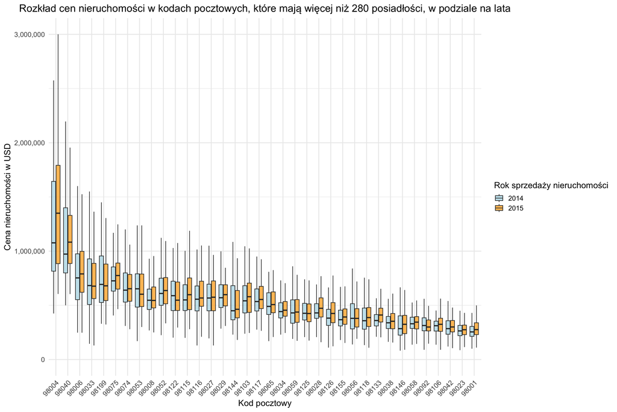

```r
zipcodes_filtered <- df %>%
  group_by(zipcode) %>%
  summarise(zipcode_count = n()) %>%
  filter(zipcode_count > 280) %>%
  pull(zipcode)

df_filtered <- df %>%
  filter(zipcode %in% zipcodes_filtered) %>%
  mutate(sell_year = substr(date, 1, 4)) %>%
  group_by(zipcode) %>%
  mutate(mean_price = mean(price, na.rm = TRUE)) %>%
  ungroup() %>%
  mutate(zipcode = fct_reorder(as.factor(zipcode), desc(mean_price)))

ggplot(df_filtered, aes(y = price, x = zipcode, fill = sell_year)) +
  geom_boxplot(alpha = 0.7, outlier.shape = NA) +
  labs(
    title = "Rozkład cen nieruchomości w kodach pocztowych, które mają więcej niż 280 posiadłości, w podziale na lata",
    y = "Cena nieruchomości w USD",
    x = "Kod pocztowy",
    fill = "Rok sprzedaży nieruchomości"
  ) +
  scale_fill_manual(
    values = c("2014" = "lightblue", "2015" = "orange")
  ) +
  theme_minimal(base_size = 15) +
  theme(
    plot.title = element_text(hjust = 0.5),
    axis.text.x = element_text(angle = 45, hjust = 1)
  ) +
  scale_y_continuous(labels = scales::comma)+
  coord_cartesian(ylim = c(0, 3000000))
```

**Komentarz:** Wykres przedstawia rozkład cen w kodach pocztowych, które mają conajmniej 280 nieruchomości, w podziale na lata. Dla czytelności wykresu, wartości odstające nie zostały zaznaczone na wykresie. Kody pocztowe zostały posortowane według średniej ceny w obu latach. W większości lokalizacji nie obserwujemy dużych różnic w rozkładach cen dla obu lat. Zauważalne są grupy kodów, w których ceny mają zbliżony rozstęp międzykwartylowy i zakres cen. Szczególnie wyróżniają się dwie pierwsze lokalizacje (kody 98004, 98040), gdzie dolny kwartyl cen przewyższa górny kwartyl w wielu innych lokalizacjach. W tych kodach widoczne są także ekstremalne wartości maksymalne.

## Zadanie 2

Czy jest różnica w rozkładzie ceny nierchomości od powierzchni mieszkalnej uwzględniając podział na nieruchomości z piwnicą i bez?

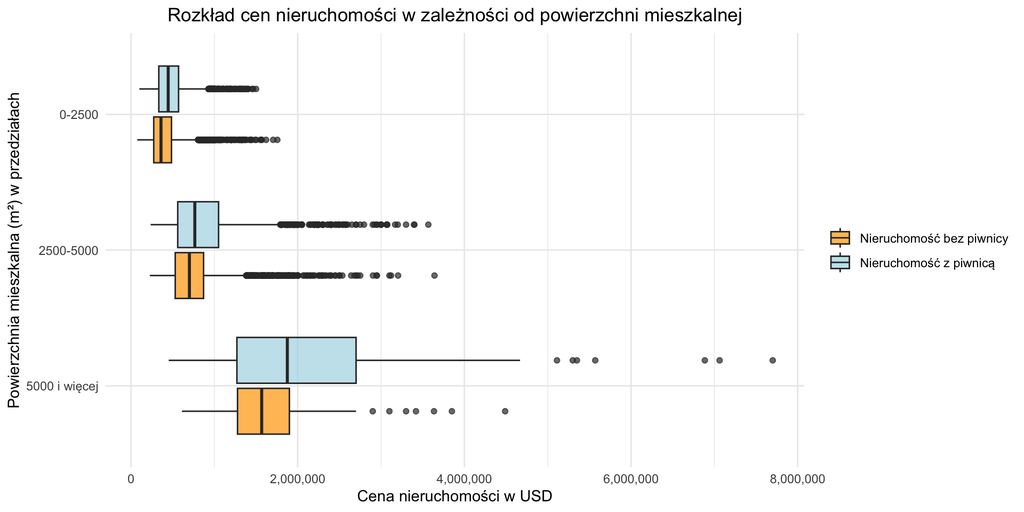

```r
# Tu umieść kod do wygenerowania odpowiedzi do zadania.
df <- df %>%
  mutate(
    has_basement = ifelse(sqft_basement > 0, TRUE, FALSE),
    sqft_group = cut(sqft_living,
                     breaks = c(0, 2500, 5000, Inf),
                     labels = c("0-2500", "2500-5000", "5000 i więcej"),
                     right = FALSE)
  )

ggplot(df, aes(x = fct_rev(sqft_group), y = price, fill = has_basement)) +
  geom_boxplot(alpha = 0.7) +
  labs(
    title = "Rozkład cen nieruchomości w zależności od powierzchni mieszkalnej",
    x = "Powierzchnia mieszkalna (m²) w przedziałach",
    y = "Cena nieruchomości w USD",
    fill = NULL
  ) +
  scale_fill_manual(values = c( "FALSE" = "orange", "TRUE" = "lightblue"),
                    labels = c("TRUE" = "Nieruchomość z piwnicą", "FALSE" = "Nieruchomość bez piwnicy")) +
  scale_y_continuous(labels = scales::comma) +
  theme_minimal() +
  coord_flip() +
  theme(
    plot.title = element_text(hjust = 0.5)
  )
```

**Komentarz:** Wykres pokazuje, że dla nieruchomości o powierzchni mieszkalnej mniejszej niż 2500 m^2 oraz przedziału powierzchni 2500-5000m^2 rozkład ceny nieruchomości od powierzchni mieszkalnej jest zbliżony dla nieruchomości zarówno z piwnicą jak i bez. Dla nieruchomości bez piwnicy wartości dolnego kwartyla, mediany oraz górnego kwartyla są niższe niż w przypadku nieruchomości z piwnicą w tym przedziale powierzchni. Największa różnica zauważalna jest dla nieruchomości o powierzchni mieszkalnej większej niż 5000 m^2. W tym przypadku wartość górnego kwartyla dla nieruchomości bez piwnicy jest zbliżona do mediany rozkładu cen nieruchomości z piwnicą. W ogólności zauważalna jest różnica między rozkładem ceny nieruchomości od powierzchni mieszkalnej dla nieruchomości z piwnicą i bez.

## Zadanie 3

Jaka jest zależność pomiędzy jakością wykończenia nieruchomości a liczbą pięter?

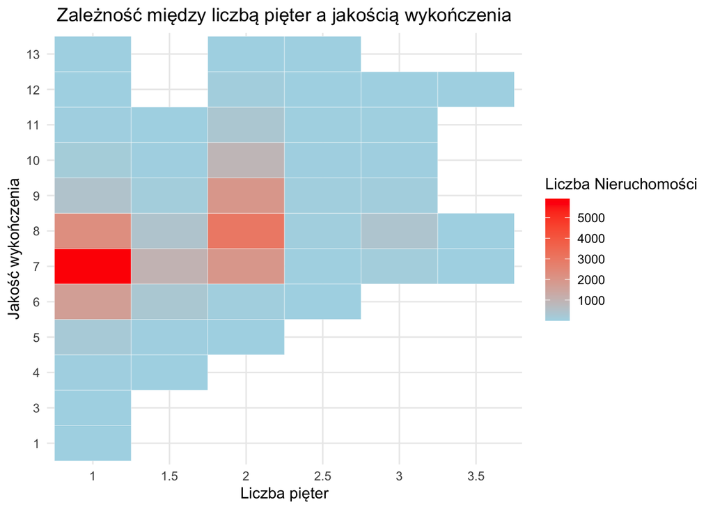

```r
# Tu umieść kod do wygenerowania odpowiedzi do zadania.

df %>%
  count(floors, grade) %>%
  ggplot(aes(x = as.factor(floors), y = as.factor(grade), fill = n)) +
  geom_tile(color = "white") +
  scale_fill_gradient(
    low = "lightblue", high = "red", name = "Liczba Nieruchomości",
  ) +
  labs(
    title = "Zależność między liczbą pięter a jakością wykończenia",
    x = "Liczba pięter",
    y = "Jakość wykończenia"
  ) +
  theme_minimal() +
  theme(
    plot.title = element_text(hjust = 0.5)
  )
```

**Komentarz:** Jedynie budynki jednopiętrowe występują w każdej jakości wykończenia. Wraz z wzrostem liczby pięter wzrasta minimalna jakość wykończenia. Natomiast, dla każdej liczby pięter najczęściej występuje jakość wykończenia na poziomie 7 lub 8. Można zauważyć, że w dostępnych danych najwięcej jest budynków 1 lub 2 piętrowych.

## Zadanie 4

Jaka jest zależność między powierzchnią mieszkalną nieruchomości a powierzchnią gruntu w podziale na liczbę sypialni?

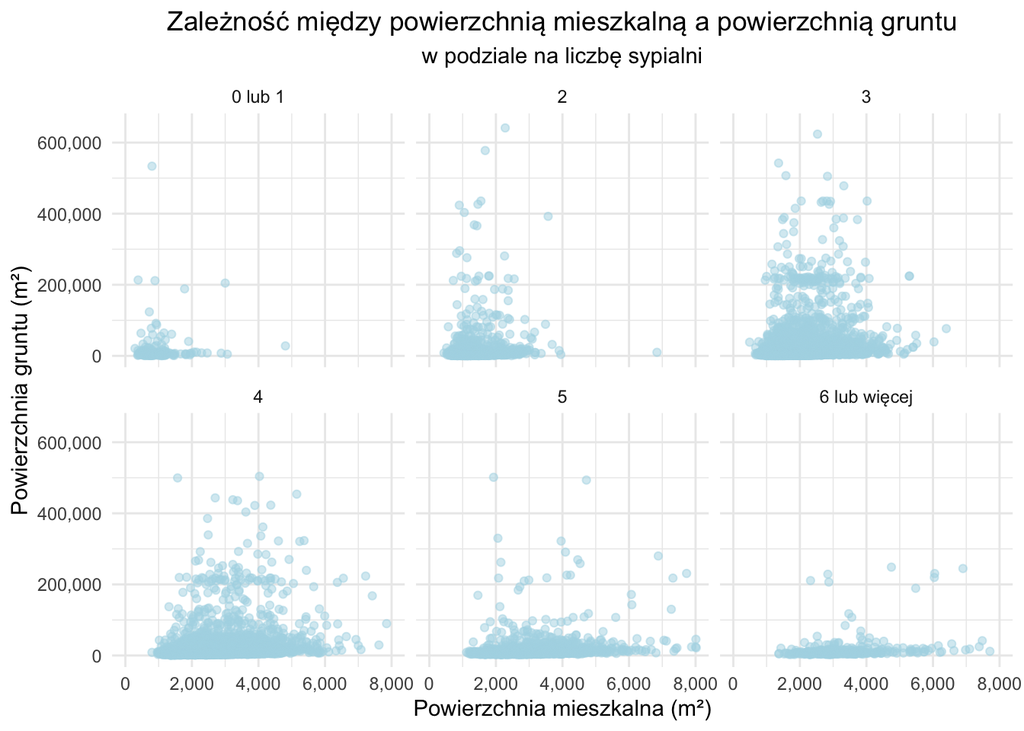

```r
df %>%
  mutate(bedrooms = case_when(
    bedrooms %in% c(0, 1) ~ "0 lub 1",
    bedrooms >= 6 ~ "6 lub więcej",
    TRUE ~ as.character(bedrooms)
  )) %>%
  ggplot(aes(x = sqft_living, y = sqft_lot)) +
  geom_point(alpha = 0.5, color = "lightblue") +
  labs(
    title = "Zależność między powierzchnią mieszkalną a powierzchnią gruntu",
    subtitle = "w podziale na liczbę sypialni",
    x = "Powierzchnia mieszkalna (m²)",
    y = "Powierzchnia gruntu (m²)"
  ) +
  theme_minimal() +
  theme(
    plot.title = element_text(hjust = 0.5),
    plot.subtitle = element_text(hjust = 0.5)
  ) +
  facet_wrap(~ bedrooms) +
  scale_y_continuous(labels = scales::comma) +
  coord_cartesian(ylim = c(0,650000),
                  xlim = c(0,8000)) +
  scale_x_continuous(labels = scales::comma)
```

```r
outside_count = sum(df$sqft_living > 8000 | df$sqft_lot > 650000, na.rm = TRUE)
outside_percentage = (outside_count / nrow(df)) * 100
```

## Zadanie 5

Rozważmy tylko nieruchomości, które miały remont. W której dekadzie było najwięcej przeprowadzonych remontów? Czy w poszczególnych dekadach jest porównywalny procent nieruchmości dla każdej wartości miary jakości i wykończenia nieruchomości?

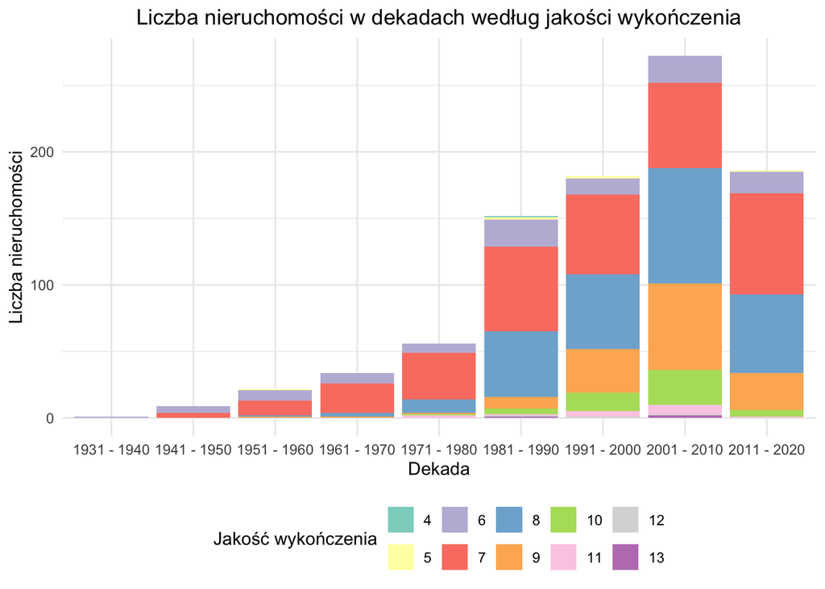

```r
# Tu umieść kod do wygenerowania odpowiedzi do zadania.

df_remodeled <- df %>%
  filter(yr_renovated > 0)  %>%
  mutate(decade = paste(floor(yr_renovated / 10) * 10 + 1,
                        "-",
                        floor(yr_renovated / 10) * 10 + 10,
                        sep = " "))

quality_counts <- df_remodeled %>%
  group_by(decade, grade) %>%
  summarise(count = n(), .groups = 'drop')

ggplot(quality_counts, aes(x = decade, y = count, fill = as.factor(grade))) +
  geom_bar(stat = "identity") +
  labs(title = "Liczba nieruchomości w dekadach według jakości wykończenia",
       x = "Dekada",
       y = "Liczba nieruchomości",
       fill = "Jakość wykończenia") +
    theme_minimal() +
  theme(
    plot.title = element_text(hjust = 0.5),
    legend.position = "bottom"
  ) +
  scale_fill_brewer(palette = "Set3") +
  scale_y_continuous(labels = scales::comma)
```

## Zadanie 6

Jak prezentuje się wartość minimalna, średnia i maksymalna ceny nieruchmości w podziele na rok budowy nieruchomości.

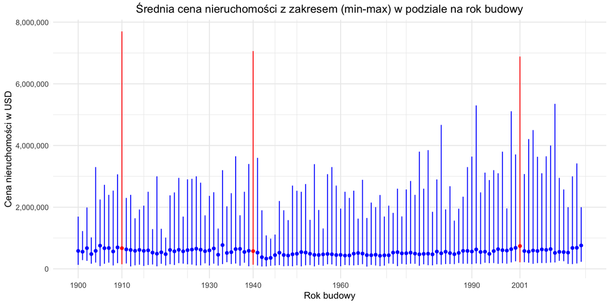

```r
price_summary <- df %>%
  group_by(yr_built) %>%
  summarise(
    min_price = min(price, na.rm = TRUE),
    avg_price = mean(price, na.rm = TRUE),
    max_price = max(price, na.rm = TRUE)
  ) %>%
  ungroup()

top_years <- price_summary %>%
  arrange(desc(max_price)) %>%
  slice(1:3) %>%
  pull(yr_built)

year_breaks <- seq(min(df$yr_built), max(df$yr_built),, by = 30)
x_breaks <- unique(c(year_breaks, top_years))

price_summary %>%
  ggplot(aes(x = yr_built, y = avg_price)) +
  geom_pointrange(aes(ymin = min_price, ymax = max_price, color = ifelse(yr_built %in% top_years, "top_year", "normal")), size = 0.2, show.legend = FALSE) +
  scale_color_manual(values = c("normal" = "blue", "top_year" = "red")) +
  labs(title = "Średnia cena nieruchomości z zakresem (min-max) w podziale na rok budowy",
       x = "Rok budowy",
       y = "Cena nieruchomości w USD") +
  scale_x_continuous(breaks = x_breaks) +  # Show every 25 years plus top years
  theme_minimal() +
  scale_y_continuous(labels = scales::comma) +
  theme(
    plot.title = element_text(hjust = 0.5)
  )
```

**Komentarz:** Minimalna oraz średnia cena nieruchomości w poszczególnych latach utrzymują się na podobnym poziomie. Największe wahania na przestrzeni lat zauważalne są w maksymalnej cenie nieruchomości. W latach 1910, 1940 oraz 2001 maksymalne ceny nieruchomości osiągały skrajne wyniki, większe od 6 mln USD. W większości lat wartość maksymalna cena nieruchomości zawiera się w przedziale 1-4 mln USD.